# Online Resource 1

Pazan, K., Dusseldorp, G.L., & Schmid, V.C.

2026-09-10

## Information

This document contains the code and data used for the paper, “Spall in good time: reassessing bipolar flaking in Late Pleistocene southern Africa” submitted to the *Journal of Archaeological Method and Theory*.

## Download data

You will need to download the data and color palettes below. Data are available both in rds and csv format.  
UMH_milky_dims csv  
UMH_milky_dims rds  
MLK_cores csv  
MLK_cores rds  
UMH_palette  
MLK_palette

You will also need to have the following packages downloaded for the .Rmd file to work properly: tidyverse, dplyr, rstatix, MASS, DescTools, MKinfer, Hotelling, factoextra, FactoMineR, vegan, ggplot2, ggpubr, rmarkdown, knitr

```r
UMH_milky_dims <- readRDS("UMH_milky_dims.rds")
MLK_cores <- readRDS("MLK_cores.rds")
UMH_palette <- readRDS("UMH_palette.rds")
MLK_palette <- readRDS("MLK_palette.rds")
set.seed(123)
```

## Outlier analysis

We conducted multivariate outlier detection using Mahalanobis distances in the package *rstatix* (Kassambara 2026). Mahalonobis distance quantifies the likelihood than a multivariate observation belongs to a particular group. When used on a single group, it detects observations that are outliers relative to the group as a whole (Bakker 2026).

### Umhlatuzana milky quartz

```r
library(tidyverse)
library(rstatix)
UMH_outlier_analysis <- UMH_milky_dims[,c(1:4)] %>% mahalanobis_distance()
UMH_outliers <- UMH_outlier_analysis %>% filter(is.outlier == TRUE)
print(UMH_outliers)
```

```
## [1] Core length    Core width     Core thickness Weight         mahal.dist
## [6] is.outlier
## <0 rows> (or 0-length row.names)
```

No multivariate outliers were detected.

### Melikane CCS bipolar cores

```r
MLK_BP_analysis2 <- MLK_cores[MLK_cores$Type=="Bipolar",c(10,19:21)] %>% mahalanobis_distance()
BP_outliers2 <- MLK_BP_analysis2 %>% filter(is.outlier == TRUE)
print(BP_outliers2)
```

```
## # A tibble: 0 × 6
## # ℹ 6 variables: Weight <dbl>, Core length <dbl>, Core width <dbl>,
## #   Core thickness <dbl>, mahal.dist <dbl>, is.outlier <lgl>
```

No multivariate outliers were detected.

### Melikane CCS freehand cores

```r
MLK_freehand_analysis2 <- MLK_cores[MLK_cores$Type=="Freehand",c(10,19:21)] %>% mahalanobis_distance()
freehand_outliers2 <- MLK_freehand_analysis2 %>% filter(is.outlier == TRUE)
print(freehand_outliers2)
```

```
## # A tibble: 1 × 6
##   Weight `Core length` `Core width` `Core thickness` mahal.dist is.outlier
##    <dbl>         <dbl>        <dbl>            <dbl>      <dbl> <lgl>
## 1   85.4            71           34             29.2       25.1 TRUE
```

One multivariate outlier was removed from the dataframe. The Melikane dataset now consists of 34 freehand and 25 bipolar cores.

```r
MLK_cleaned <- MLK_cores[MLK_cores$Weight<=85.3,]
xtabs(~Type, MLK_cleaned)
```

```
## Type
## Freehand  Bipolar
##       34       25
```

## Data preparation

A dataframe was created consisting of the Melikane and Umhlatuzana bipolar cores. Geometric mean was added as a variable to the bipolar data frame, and log-shape variables were calculated (Mosimann and James 1979; Darroch and Mosimann 1985). The geometric mean can be calculated by exponentiating the mean of the logged variables (length, width, and thickness), expressed by the function used to create `bipolar$GM` as shown in the code block below. The log-shape variables (`bipolar_shape`) were created by taking the log of the ratio of each variable to the geometric mean.

```r
MLK_BPdims <- MLK_cleaned[MLK_cleaned$Type=="Bipolar",c("Core length","Core width","Core thickness", "Weight")]
MLK_BPdims$Site <- "MLK"
bipolar <- rbind(UMH_milky_dims, MLK_BPdims)
bipolar$GM <- exp(rowMeans(log(bipolar[, c("Core length", "Core width", "Core thickness")])))
bipolar_shape <- log(bipolar[, c("Core length", "Core width", "Core thickness")] /bipolar$GM)
```

Geometric mean was also added to the dataframe of all Melikane cores.

```r
MLK_cleaned$GM<- exp(rowMeans(log(MLK_cleaned[, c("Core length", "Core width", "Core thickness")])))
```

## Comparison of mean dimensions

Only core thickness had a p-value <.05 and a 95% confidence interval excluding 0.

```r
set.seed(123)
lapply(bipolar[,c(1:4,6)], function(i) perm.t.test(i~bipolar$Site))
```

```
## $`Core length`
##
##  Permutation Welch Two Sample t-test
##
## data:  i by bipolar$Site
## number of permutations:  9999
## (Monte-Carlo) permutation p-value = 0.2744
## permutation difference of means (SE) = 3.285038 (2.637096)
## 95 percent (Monte-Carlo) permutation percentile confidence interval:
##  -1.964185  8.320828
##
## Results without permutation:
## t = 1.1163, df = 16.854, p-value = 0.28
## alternative hypothesis: true difference in means is not equal to 0
## 95 percent confidence interval:
##  -2.919291  9.470224
## sample estimates:
## mean in group MLK mean in group UMH
##          23.28880          20.01333
##
##
## $`Core width`
##
##  Permutation Welch Two Sample t-test
##
## data:  i by bipolar$Site
## number of permutations:  9999
## (Monte-Carlo) permutation p-value = 0.08611
## permutation difference of means (SE) = 4.046859 (1.983737)
## 95 percent (Monte-Carlo) permutation percentile confidence interval:
##  0.1639383 7.8896617
##
## Results without permutation:
## t = 1.7922, df = 14.693, p-value = 0.09372
## alternative hypothesis: true difference in means is not equal to 0
## 95 percent confidence interval:
##  -0.7809017  8.9369017
## sample estimates:
## mean in group MLK mean in group UMH
##            17.018            12.940
```

[output cut: 48 more lines]

```
## data:  i by bipolar$Site
## number of permutations:  9999
## (Monte-Carlo) permutation p-value = 0.06251
## permutation difference of means (SE) = 3.743777 (1.696328)
## 95 percent (Monte-Carlo) permutation percentile confidence interval:
##  0.4812936 7.0359475
##
## Results without permutation:
## t = 1.9326, df = 14.655, p-value = 0.07285
## alternative hypothesis: true difference in means is not equal to 0
## 95 percent confidence interval:
##  -0.3922325  7.8509218
## sample estimates:
## mean in group MLK mean in group UMH
##          16.87901          13.14967
```

Welch’s permutation t-tests were also performed to assess differences between Melikane freehand and bipolar cores. In these instances, bipolar cores were smaller in all dimensions.

```r
MLK_cleaned <- MLK_cleaned %>% mutate(Type=fct_relevel(Type, "Bipolar", "Freehand"))
lapply(MLK_cleaned[,c(10,19:21,26)], function(i) perm.t.test(i~MLK_cleaned$Type))
```

```
## $Weight
##
##  Permutation Welch Two Sample t-test
##
## data:  i by MLK_cleaned$Type
## number of permutations:  9999
## (Monte-Carlo) permutation p-value = 0.0005001
## permutation difference of means (SE) = -8.533915 (2.854459)
## 95 percent (Monte-Carlo) permutation percentile confidence interval:
##  -13.833338  -2.897236
##
## Results without permutation:
## t = -3.5527, df = 51.019, p-value = 0.0008312
## alternative hypothesis: true difference in means is not equal to 0
## 95 percent confidence interval:
##  -13.407207  -3.725758
## sample estimates:
##  mean in group Bipolar mean in group Freehand
##                7.84440               16.41088
##
##
## $`Core length`
##
##  Permutation Welch Two Sample t-test
##
## data:  i by MLK_cleaned$Type
## number of permutations:  9999
## (Monte-Carlo) permutation p-value = 0.0009001
## permutation difference of means (SE) = -6.990576 (2.154167)
## 95 percent (Monte-Carlo) permutation percentile confidence interval:
##  -11.194476  -2.671718
##
## Results without permutation:
## t = -3.6448, df = 56.204, p-value = 0.0005856
## alternative hypothesis: true difference in means is not equal to 0
## 95 percent confidence interval:
##  -10.806497  -3.141197
## sample estimates:
##  mean in group Bipolar mean in group Freehand
##               23.28880               30.26265
```

[output cut: 48 more lines]

```
## data:  i by MLK_cleaned$Type
## number of permutations:  9999
## (Monte-Carlo) permutation p-value < 1e-04
## permutation difference of means (SE) = -4.889113 (1.430386)
## 95 percent (Monte-Carlo) permutation percentile confidence interval:
##  -7.640846 -2.068727
##
## Results without permutation:
## t = -4.0564, df = 55.977, p-value = 0.0001559
## alternative hypothesis: true difference in means is not equal to 0
## 95 percent confidence interval:
##  -7.317621 -2.479351
## sample estimates:
##  mean in group Bipolar mean in group Freehand
##               16.87901               21.77750
```

### Shape vs. size

To confirm that there were no predictable changes in shape relative to size in the bipolar core sample, we first checked the log-shape variables for normality using Shapiro-Wilk Tests and then performed pairwise Pearsons product-moment correlations between the log shape variables and the log geometric mean (Falsetti et al. 1993). There were no correlations between the shape variables and size, indicating isometry. Having established that shape differences could not be explained by size, we therefore felt it was appropriate to continue with our PCA.

```r
bipolar$logGM <- log(bipolar$GM)
lapply(bipolar_shape[, 1:3], shapiro.test)
```

```
## $`Core length`
##
##  Shapiro-Wilk normality test
##
## data:  X[[i]]
## W = 0.95458, p-value = 0.1355
##
##
## $`Core width`
##
##  Shapiro-Wilk normality test
##
## data:  X[[i]]
## W = 0.97638, p-value = 0.606
##
##
## $`Core thickness`
##
##  Shapiro-Wilk normality test
##
## data:  X[[i]]
## W = 0.96954, p-value = 0.3959
```

```r
lapply(bipolar_shape[,c(1:3)], function(i) cor.test(i, bipolar$logGM, method="pearson"))
```

```
## $`Core length`
##
##  Pearson's product-moment correlation
##
## data:  i and bipolar$logGM
## t = -1.1131, df = 35, p-value = 0.2733
## alternative hypothesis: true correlation is not equal to 0
## 95 percent confidence interval:
##  -0.4801550  0.1479818
## sample estimates:
##        cor
## -0.1849031
##
##
## $`Core width`
##
##  Pearson's product-moment correlation
##
## data:  i and bipolar$logGM
## t = 1.4475, df = 35, p-value = 0.1567
## alternative hypothesis: true correlation is not equal to 0
## 95 percent confidence interval:
##  -0.09356026  0.52152149
## sample estimates:
##       cor
## 0.2376636
##
##
## $`Core thickness`
##
##  Pearson's product-moment correlation
##
## data:  i and bipolar$logGM
## t = -0.15583, df = 35, p-value = 0.8771
## alternative hypothesis: true correlation is not equal to 0
## 95 percent confidence interval:
##  -0.3473866  0.3002492
## sample estimates:
##         cor
## -0.02633144
```

## Principal components analysis

PCA was conducted on scaled log-shape variables for the Melikane and Umhlatuzana bipolar cores. PCA constructs new, uncorrelated variables - “principal components” - from a larger set of correlated variables. The PCs are synthesized from the original variables, allowing us to assess how aspects of core dimensions relate to one another and contribute to variation in shape. The log-shape variables were scaled to account for differences in variance, allowing each variable to contribute equally to the result (Bakker 2026).

```r
bipolar_pca <- prcomp(bipolar_shape, scale. = TRUE)
bipolar_pca
```

```
## Standard deviations (1, .., p=3):
## [1] 1.331174e+00 1.108141e+00 1.928720e-15
##
## Rotation (n x k) = (3 x 3):
##                       PC1        PC2       PC3
## Core length    -0.7490643  0.0682623 0.6589711
## Core width      0.5546150  0.6086632 0.5673899
## Core thickness  0.3623601 -0.7904868 0.4937872
```

```r
summary(bipolar_pca)
```

```
## Importance of components:
##                           PC1    PC2       PC3
## Standard deviation     1.3312 1.1081 1.929e-15
## Proportion of Variance 0.5907 0.4093 0.000e+00
## Cumulative Proportion  0.5907 1.0000 1.000e+00
```

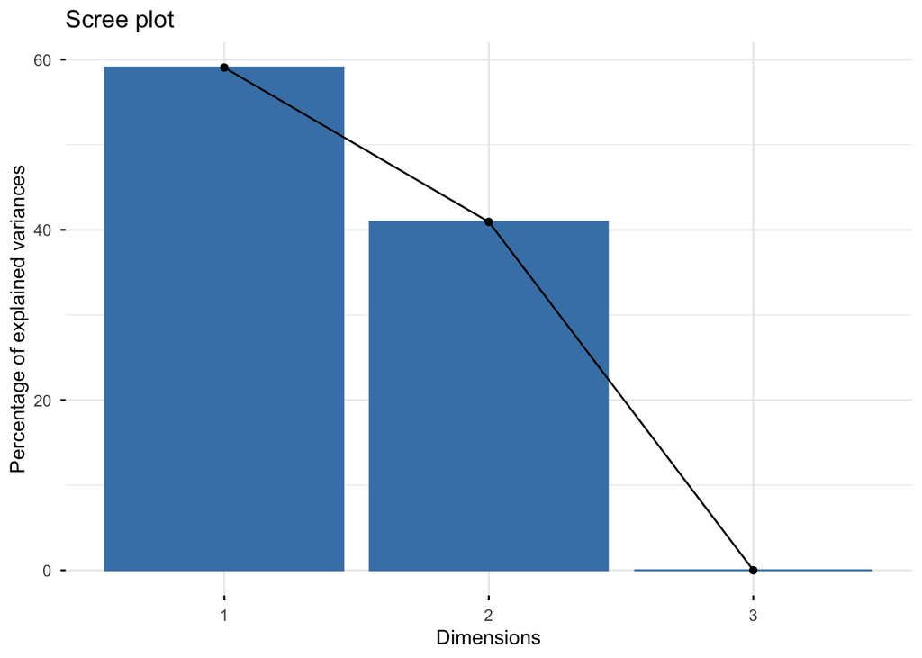

Values for PC1 and PC2 were added to the data frame of bipolar cores, and a biplot was visualized using PCs 1 and 2.

```r
bipolar$PC1 <- bipolar_pca$x[,1]
bipolar$PC2 <- bipolar_pca$x[,2]
```

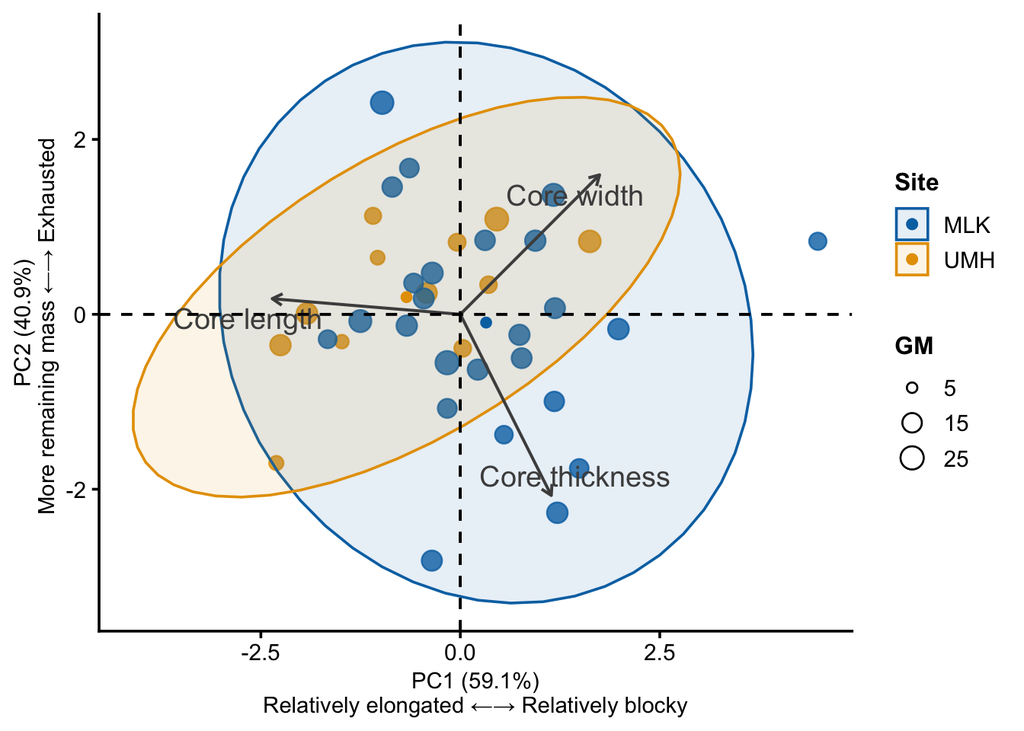

## Evaluating PCA results

### Multivariate differences

We conducted a Permutation Hotellings T Test in the package *Hotelling* (Curran and Hersh 2021) to look for multivariate shape differences between the Umhlatuzana and Melikane cores. The test did not detect significant multivariate differences in means.

```r
library(Hotelling)
hotelling_bipolar <-
hotelling.test(PC1+PC2~Site, data = bipolar, perm=TRUE, B=10000)
```

```r
print(hotelling_bipolar)
```

```
## Test stat:  2.8168
## Numerator df:  2
## Denominator df:  34
## Permutation P-value:  0.0701
## Number of permutations : 10000
```

We conducted a test of multivariate dispersion in the package *vegan* (Oksanen et al. 2026), followed by ANOVA to assess significance according to the procedures in Bakker (2026). The test did not detect significant differences in multivariate dispersion.

```r
library(vegan)
bipolar_dispersion <- betadisper(d=dist(bipolar[,c("PC1","PC2")]), group=bipolar$Site, type="centroid")
bipolar_dispersion
```

```
##
##  Homogeneity of multivariate dispersions
##
## Call: betadisper(d = dist(bipolar[, c("PC1", "PC2")]), group =
## bipolar$Site, type = "centroid")
##
## No. of Positive Eigenvalues: 2
## No. of Negative Eigenvalues: 0
##
## Average distance to centroid:
##   MLK   UMH
## 1.509 1.243
##
## Eigenvalues for PCoA axes:
## PCoA1 PCoA2
## 63.79 44.21
```

```r
anova(bipolar_dispersion)
```

```
## Analysis of Variance Table
##
## Response: Distances
##           Df  Sum Sq Mean Sq F value Pr(>F)
## Groups     1  0.5714 0.57140  0.8417 0.3652
## Residuals 35 23.7612 0.67889
```

We conducted Linear Discriminant Analysis (LDA) in the *MASS* package (Venables and Ripley 2002), asking whether the values of PC1 and PC2 could be used to assign cores to the correct site. We used proportional prior probabilities to account for differences in sample size, and used the cross-validation option built into the lda() function to assess the model’s accuracy according to procedures in Carlson (2017).

```r
library(MASS)
bipolar.lda <- lda(Site~PC1+PC2, data=bipolar, CV=TRUE)
bipolar.lda.table <- table(Observed=bipolar$Site, Predicted=bipolar.lda$class)
bipolar.lda.table
```

```
##         Predicted
## Observed MLK UMH
##      MLK  20   5
##      UMH   9   3
```

Model accuracy was 0.62, indicating that the model assigned only 62% of the cores to the correct site.

```r
lda_accuracy <- mean(bipolar.lda$class == bipolar$Site)
print(lda_accuracy)
```

```
## [1] 0.6216216
```

### Univariate differences

We separated PC1 and PC2 to evaluate intersite univariate differences. While the sites differed significantly along PC1, no difference was detected along PC2.

```r
lapply(bipolar[,c("PC1","PC2")], function(i) perm.t.test(i~bipolar$Site))
```

```
## $PC1
##
##  Permutation Welch Two Sample t-test
##
## data:  i by bipolar$Site
## number of permutations:  9999
## (Monte-Carlo) permutation p-value = 0.0305
## permutation difference of means (SE) = 1.002426 (0.4634715)
## 95 percent (Monte-Carlo) permutation percentile confidence interval:
##  0.06034552 1.89117055
##
## Results without permutation:
## t = 2.2963, df = 22.894, p-value = 0.03115
## alternative hypothesis: true difference in means is not equal to 0
## 95 percent confidence interval:
##  0.09872555 1.89745019
## sample estimates:
## mean in group MLK mean in group UMH
##         0.3237042        -0.6743837
##
##
## $PC2
##
##  Permutation Welch Two Sample t-test
##
## data:  i by bipolar$Site
## number of permutations:  9999
## (Monte-Carlo) permutation p-value = 0.3971
## permutation difference of means (SE) = -0.2923541 (0.38732)
## 95 percent (Monte-Carlo) permutation percentile confidence interval:
##  -1.0278050  0.4664001
##
## Results without permutation:
## t = -0.85715, df = 31.258, p-value = 0.3979
## alternative hypothesis: true difference in means is not equal to 0
## 95 percent confidence interval:
##  -0.9829869  0.4011002
## sample estimates:
## mean in group MLK mean in group UMH
##        -0.0943600         0.1965833
```

Having established that the Umhlatuzana cores were significantly more elongated, we wanted to know whether at Umhaltuzana in particular, there was a relationship between elongation and exhaustion. We conducted a Shapiro-Wilk Test to confirm normality in *rstatix* (Kassambara 2026), and then conducted a Pearson’s product-moment correlation on PC1 and PC2. This revealed a significant, positive, moderately strong correlation between axes, indicating that cores with higher values on PC1 (chunkier cores) were also more likely to have higher values on PC2, indicating greater exhaustion. More elongated cores (lower values on PC1) were also more likely to have more remaining uselife (lower values on PC2).

```r
shapiro_test(bipolar[bipolar$Site=="UMH",], vars = c("PC1","PC2"))
```

```
## # A tibble: 2 × 3
##   variable statistic     p
##   <chr>        <dbl> <dbl>
## 1 PC1          0.956 0.731
## 2 PC2          0.907 0.195
```

```r
cor.test(bipolar$PC1[bipolar$Site=="UMH"], bipolar$PC2[bipolar$Site=="UMH"], method="pearson")
```

```
##
##  Pearson's product-moment correlation
##
## data:  bipolar$PC1[bipolar$Site == "UMH"] and bipolar$PC2[bipolar$Site == "UMH"]
## t = 2.4715, df = 10, p-value = 0.03302
## alternative hypothesis: true correlation is not equal to 0
## 95 percent confidence interval:
##  0.06480064 0.87904137
## sample estimates:
##       cor
## 0.6158011
```

This correlation was not present within the Melikane data. (Spearman’s rank correlation was used, due to rejection of normality for PC1.)

```r
shapiro_test(bipolar[bipolar$Site=="MLK",], vars = c("PC1","PC2"))
```

```
## # A tibble: 2 × 3
##   variable statistic      p
##   <chr>        <dbl>  <dbl>
## 1 PC1          0.907 0.0263
## 2 PC2          0.989 0.991
```

```r
cor.test(bipolar$PC1[bipolar$Site=="MLK"], bipolar$PC2[bipolar$Site=="MLK"], method="spearman")
```

```
##
##  Spearman's rank correlation rho
##
## data:  bipolar$PC1[bipolar$Site == "MLK"] and bipolar$PC2[bipolar$Site == "MLK"]
## S = 3328, p-value = 0.1747
## alternative hypothesis: true rho is not equal to 0
## sample estimates:
##   rho
## -0.28
```

## Data

Data sets produced in this file are available below.

### bipolar

bipolar csv

|  | Core length | Core width | Core thickness | Weight | Site | GM | logGM | PC1 | PC2 |
| --- | --- | --- | --- | --- | --- | --- | --- | --- | --- |
| 8 | 10.67 | 6.31 | 4.25 | 0.20 | UMH | 6.589628 | 1.885497 | -1.03604346 | 0.647696497 |
| 11 | 15.16 | 9.19 | 5.67 | 0.80 | UMH | 9.244127 | 2.223988 | -1.09364607 | 1.126036049 |
| 14 | 33.27 | 27.68 | 16.30 | 16.00 | UMH | 24.668088 | 3.205510 | 0.45688265 | 1.088508770 |
| 17 | 12.70 | 4.83 | 5.28 | 0.30 | UMH | 6.867441 | 1.926792 | -2.30602695 | -1.700443364 |
| 18 | 13.42 | 10.32 | 7.02 | 0.80 | UMH | 9.906565 | 2.293198 | 0.35354376 | 0.338507291 |
| 20 | 10.70 | 5.36 | 4.39 | 0.20 | UMH | 6.314482 | 1.842846 | -1.48482493 | -0.312422316 |
| 22 | 32.97 | 15.47 | 12.11 | 6.80 | UMH | 18.347820 | 2.909511 | -1.92192568 | 0.009456039 |
| 26 | 15.00 | 11.04 | 6.95 | 1.20 | UMH | 10.479689 | 2.349439 | -0.03981138 | 0.824159569 |
| 27 | 24.29 | 25.20 | 14.95 | 7.90 | UMH | 20.916535 | 3.040540 | 1.62278969 | 0.833839805 |
| 29 | 14.24 | 9.69 | 7.64 | 1.10 | UMH | 10.177530 | 2.320182 | 0.03034449 | -0.389049966 |

[output cut: 27 more lines]

### bipolar_shape

bipolar_shape csv

|  | Core length | Core width | Core thickness |
| --- | --- | --- | --- |
| 8 | 0.4819392 | -0.0433612317 | -0.43857793 |
| 11 | 0.4946719 | -0.0058725417 | -0.48879936 |
| 14 | 0.2991456 | 0.1151996879 | -0.41434534 |
| 17 | 0.6148105 | -0.3519450520 | -0.26286542 |
| 18 | 0.3035484 | 0.0408860568 | -0.34443449 |
| 20 | 0.5273981 | -0.1638816728 | -0.36351642 |
| 22 | 0.5860873 | -0.1706080952 | -0.41547920 |
| 26 | 0.3586112 | 0.0520860737 | -0.41069731 |
| 27 | 0.1495247 | 0.1863039821 | -0.33582871 |
| 29 | 0.3358726 | -0.0490878858 | -0.28678471 |

[output cut: 27 more lines]

### MLK_cleaned

MLK_cleaned csv

| ID | Square | Quad | Context | Spit | Bag | Raw Material | Typology | Type | Weight | Scar number | Number of rotations | Core cortex | Core cortex type | Form last removal | Length last removal | Width last removal | Core Technology | Core length | Core width | Core thickness | Residues | Photograph Number | Illustration Number | Comments | GM | logGM | PC1 | PC2 | Shape_length | … |
| --- | --- | --- | --- | --- | --- | --- | --- | --- | --- | --- | --- | --- | --- | --- | --- | --- | --- | --- | --- | --- | --- | --- | --- | --- | --- | --- | --- | --- | --- | --- |
| 21136 | S6 | SE | 6-8 | 2 | NA | CCS (white) | Core (Bipolar) | Bipolar | 2.62 | 12 | NA | 1 | Smooth tabular | indeterminate | NA | NA | NA | 20.87 | 10.10 | 8.28 | NA | NA | NA | Very reduced bipolar core, lots of opposed scars. And crushing. | 12.03995 | 2.488230 | -0.113416684 | 0.283573395 | 0.55008235 | … |
| 21151 | S6 | SE | 6-8 | 2 | NA | CCS (light blue) | Core (Multidirectional) | Freehand | 14.35 | 13 | NA | 1 | Smooth tabular | indeterminate | NA | NA | NA | 25.76 | 22.50 | 17.40 | NA | NA | NA | Nice core. Pretty. Looks like it was used as a platform core, then rotated only 1/4 turn and used as a platform core again. Almost a perfect cube. | 21.60525 | 3.072936 | 0.185667179 | -0.066119134 | 0.17588676 | … |
| 21154 | S6 | SE | 6-8 | 2 | NA | CCS (other) | Core (Bipolar) | Bipolar | 6.02 | 14 | NA | N/A | NA | indeterminate | NA | NA | NA | 20.27 | 18.13 | 12.60 | NA | NA | NA | NA | 16.66764 | 2.813469 | 0.115556970 | -0.103236672 | 0.19567303 | … |
| 21172 | S6 | SE | 6-8 | 2 | NA | CCS (brown) | Core (Multidirectional) | Freehand | 18.15 | 11 | NA | 1 | Smooth tabular | indeterminate | NA | NA | NA | 29.55 | 24.01 | 23.09 | NA | NA | NA | Actually a pretty nice little core. | 25.39751 | 3.234651 | 0.314774478 | 0.023238149 | 0.15143248 | … |
| 21177 | S6 | SE | 6-8 | 2 | NA | CCS (greyish blue) | Core (Multidirectional) | Freehand | 4.33 | 7 | NA | 1 | Smooth tabular | indeterminate | NA | NA | NA | 23.12 | 15.53 | 8.48 | NA | NA | NA | Has crushing along opposing margins, but no intersecting scars. May have tried bipolar. | 14.49389 | 2.673727 | -0.241329920 | 0.006863949 | 0.46697067 | … |
| 21187 | S6 | SE | 6-8 | 2 | NA | CCS (maroon) | Core (Initial) | Freehand | 4.83 | 1 | NA | 2 | Rough | blade | 23.82 | 14.54 | NA | 23.92 | 15.06 | 9.49 | NA | NA | NA | NA | 15.06436 | 2.712332 | -0.166540439 | 0.075418721 | 0.46238301 | … |
| 21217 | S6 | SE | 6-8 | 2 | NA | CCS (true blue) | Core (Multidirectional) | Freehand | 3.53 | 5 | NA | 1 | Smooth tabular | indeterminate | NA | NA | Informal | 24.16 | 13.72 | 10.31 | NA | NA | NA | NA | 15.06271 | 2.712222 | -0.088410829 | 0.173131081 | 0.47247594 | … |
| 21266 | S6 | SE | 6-8 | 1 | NA | CCS (light blue) | Core (Bipolar) | Bipolar | 5.65 | 11 | NA | 0 | NA | indeterminate | NA | NA | NA | 21.72 | 17.21 | 10.66 | NA | NA | NA | Textbook BP core. Definitely photograph this one. Brian should see this too. | 15.85377 | 2.763408 | -0.045726443 | -0.059530578 | 0.31482599 | … |
| 21272 | S6 | SE | 6-8 | 1 | NA | CCS (beige) | Core (Multidirectional) | Freehand | 14.06 | 9 | 2 | 1 | Smooth other | indeterminate | NA | NA | NA | 33.80 | 26.72 | 13.47 | NA | NA | NA | Has multiple distinct platforms. Not very reduced though. You could definitely get more good flakes off of it. | 22.99889 | 3.135446 | -0.208973751 | -0.103675528 | 0.38501476 | … |
| 21273 | S6 | SE | 6-8 | 1 | NA | CCS (brown) | Core (Bipolar) | Bipolar | 22.37 | 14 | NA | 0 | NA | indeterminate | NA | NA | NA | 38.38 | 26.30 | 12.68 | NA | NA | NA | Looks like this was initially a parallel or platform core, and then turned into a BP core. Lots of crushing on the sides. | 23.39160 | 3.152377 | -0.327524037 | -0.031995912 | 0.49515936 | … |

[output cut: 49 more lines]

Bakker, Jonathan D. 2026. *Applied Multivariate Statistics in r*. University of Washington. https://uw.pressbooks.pub/appliedmultivariatestatistics/.

Carlson, David Lee. 2017. *Quantitative Methods in Archaeology Using r*. Cambridge Manuals in Archaeology. Cambridge University Press.

Curran, James, and Taylor Hersh. 2021. *Hotelling: Hotelling’s t^2 Test and Variants*. https://doi.org/10.32614/CRAN.package.Hotelling.

Darroch, John N., and James E. Mosimann. 1985. “Canonical and Principal Components of Shape.” *Biometrika* 72 (2): 241–52. https://doi.org/10.2307/2336077.

Falsetti, Anthony B., William L. Jungers, and Theodore M. Colle. 1993. “Morphometrics of the Callitrichid Forelimb: A Case Study in Size and Shape.” *International Journal of Primatology* 14 (4): 551–72. https://doi.org/10.1007/BF02215447.

Kassambara, Alboukadel. 2026. *Rstatix: Pipe-Friendly Framework for Basic Statistical Tests*. https://doi.org/10.32614/CRAN.package.rstatix.

Kohl, Matthias. 2025. *MKinfer: Inferential Statistics*. https://github.com/stamats/MKinfer.

Ludbrook, John. 1994. “Advantages of Permutation (Randomization) Tests in Clinical and Experimental Pharmacology and Physiology.” *Clinical and Experimental Pharmacology and Physiology* 21 (9): 673–86. https://doi.org/10.1111/j.1440-1681.1994.tb02570.x.

Mielke, Paul W., and Kenneth J. Berry. 1994. “Permutation Tests for Common Locations Among Samples with Unequal Variances.” *Journal of Educational and Behavioral Statistics* 19 (3): 217–36. https://doi.org/10.2307/1165295.

Mosimann, James E., and Frances C. James. 1979. “New Statistical Methods for Allometry with Application to Florida Red-Winged Blackbirds.” *Evolution* 33 (1): 444–59. https://doi.org/10.2307/2407633.

Noguchi, Kimihiro, Frank Konietschke, Fernando Marmolejo-Ramos, and Markus Pauly. 2021. “Permutation Tests Are Robust and Powerful at 0.5.” *Behavior Research Methods* 53 (6): 2712–24. https://doi.org/10.3758/s13428-021-01595-5.

Oksanen, Jari, Gavin L. Simpson, F. Guillaume Blanchet, et al. 2026. *Vegan: Community Ecology Package*. https://doi.org/10.32614/CRAN.package.vegan.

Venables, W. N., and B. D. Ripley. 2002. *Modern Applied Statistics with s*. https://www.stats.ox.ac.uk/pub/MASS4/.